# DDS Case Study

Sid Swarupananda

October 8, 2019

# Libraries used

```r
library(plyr)
library(dplyr)
library(magrittr)
library(rlang)
```

```r
library(ggplot2)
library(ggthemes)
library(knitr)
library(kableExtra)
library(class)
library(caret)
library(e1071)
library(ggthemes)
```

# 1. How many breweries are present in each state?

```r
# Read in beer and breweries data set using read.csv
Beers <- read.csv("https://raw.githubusercontent.com/BivinSadler/MDS-6306-Doing-Data-Science-Fall-2019/master/Unit%208%20and%209%20Case%20Study%201/Beers.csv", header = TRUE, sep = ",")
Breweries <- read.csv("https://raw.githubusercontent.com/BivinSadler/MDS-6306-Doing-Data-Science-Fall-2019/master/Unit%208%20and%209%20Case%20Study%201/Breweries.csv", header = TRUE, sep = ",")

BrewPerState <-table(Breweries$State)
BrewPerState
```

```
##
##  AK  AL  AR  AZ  CA  CO  CT  DC  DE  FL  GA  HI  IA  ID  IL  IN  KS  KY
##   7   3   2  11  39  47   8   1   2  15   7   4   5   5  18  22   3   4
##  LA  MA  MD  ME  MI  MN  MO  MS  MT  NC  ND  NE  NH  NJ  NM  NV  NY  OH
##   5  23   7   9  32  12   9   2   9  19   1   5   3   3   4   2  16  15
##  OK  OR  PA  RI  SC  SD  TN  TX  UT  VA  VT  WA  WI  WV  WY
##   6  29  25   5   4   1   3  28   4  16  10  23  20   1   4
```

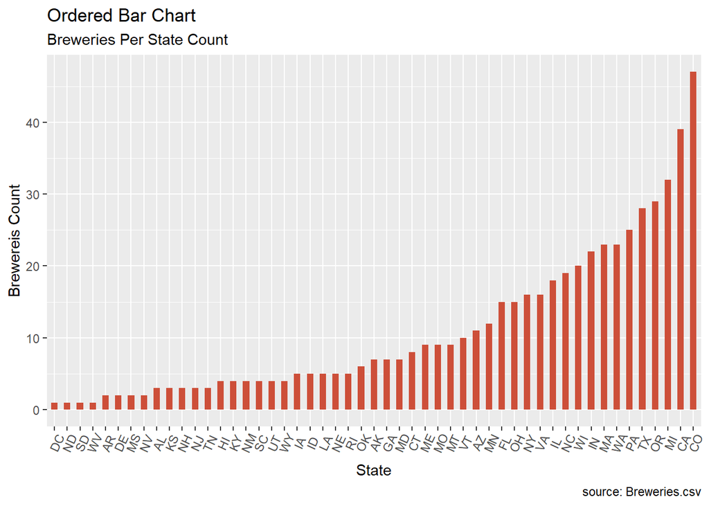

```r
Breweries %>% group_by(State) %>% summarize(count = n()) %>% ggplot(aes(x=reorder(State, count), y = count)) +
geom_bar(stat="identity", width=.5, fill="tomato3") +
labs(title="Ordered Bar Chart",
     x = "State",
     y = "Brewereis Count",
     subtitle="Breweries Per State Count",
     caption="source: Breweries.csv") +
     theme(axis.text.x = element_text(angle=65, vjust=0.6))
```

# 2. Merge beer data with the breweries data. Print the first 6 observations and the last six observations to check the merged file. (RMD only, this does not need to be included in the presentation or the deck.)

```r
detach(package:plyr)
library(dplyr)
# Renamed Brewery_id to Brew_ID to satisfy merging requirement
Beers <- rename(Beers, Brew_ID = Brewery_id)
BrewPub <- merge(Beers, Breweries, by="Brew_ID")

# Change variable names to more meaningful title
BrewPub <- full_join(Beers, Breweries, by="Brew_ID")

#kable - Used to create tables in LaTeX, HTML, Markdown and reStructuredText
# First 6 observations of the merged file
kable(head(BrewPub,6))
```

| Name.x | Beer_ID | ABV | IBU | Brew_ID | Style | Ounces | Name.y | City | State |
| --- | --- | --- | --- | --- | --- | --- | --- | --- | --- |
| Pub Beer | 1436 | 0.050 | NA | 409 | American Pale Lager | 12 | 10 Barrel Brewing Company | Bend | OR |
| Devil’s Cup | 2265 | 0.066 | NA | 178 | American Pale Ale (APA) | 12 | 18th Street Brewery | Gary | IN |
| Rise of the Phoenix | 2264 | 0.071 | NA | 178 | American IPA | 12 | 18th Street Brewery | Gary | IN |
| Sinister | 2263 | 0.090 | NA | 178 | American Double / Imperial IPA | 12 | 18th Street Brewery | Gary | IN |
| Sex and Candy | 2262 | 0.075 | NA | 178 | American IPA | 12 | 18th Street Brewery | Gary | IN |
| Black Exodus | 2261 | 0.077 | NA | 178 | Oatmeal Stout | 12 | 18th Street Brewery | Gary | IN |

```r
# Last 6 observations of the merged file
kable(tail(BrewPub,6))
```

|  | Name.x | Beer_ID | ABV | IBU | Brew_ID | Style | Ounces | Name.y | City | State |
| --- | --- | --- | --- | --- | --- | --- | --- | --- | --- | --- |
| 2405 | Rocky Mountain Oyster Stout | 1035 | 0.075 | NA | 425 | American Stout | 12 | Wynkoop Brewing Company | Denver | CO |
| 2406 | Belgorado | 928 | 0.067 | 45 | 425 | Belgian IPA | 12 | Wynkoop Brewing Company | Denver | CO |
| 2407 | Rail Yard Ale | 807 | 0.052 | NA | 425 | American Amber / Red Ale | 12 | Wynkoop Brewing Company | Denver | CO |
| 2408 | B3K Black Lager | 620 | 0.055 | NA | 425 | Schwarzbier | 12 | Wynkoop Brewing Company | Denver | CO |
| 2409 | Silverback Pale Ale | 145 | 0.055 | 40 | 425 | American Pale Ale (APA) | 12 | Wynkoop Brewing Company | Denver | CO |
| 2410 | Rail Yard Ale (2009) | 84 | 0.052 | NA | 425 | American Amber / Red Ale | 12 | Wynkoop Brewing Company | Denver | CO |

# 3. Address the missing values in each column.

```r
summary(BrewPub)
```

```
##                     Name.x        Beer_ID            ABV
##  Nonstop Hef Hop       :  12   Min.   :   1.0   Min.   :0.00100
##  Dale's Pale Ale       :   6   1st Qu.: 808.2   1st Qu.:0.05000
##  Oktoberfest           :   6   Median :1453.5   Median :0.05600
##  Longboard Island Lager:   4   Mean   :1431.1   Mean   :0.05977
##  1327 Pod's ESB        :   3   3rd Qu.:2075.8   3rd Qu.:0.06700
##  Boston Lager          :   3   Max.   :2692.0   Max.   :0.12800
##  (Other)               :2376                    NA's   :62
##       IBU            Brew_ID                                 Style
##  Min.   :  4.00   Min.   :  1.0   American IPA                  : 424
##  1st Qu.: 21.00   1st Qu.: 94.0   American Pale Ale (APA)       : 245
##  Median : 35.00   Median :206.0   American Amber / Red Ale      : 133
##  Mean   : 42.71   Mean   :232.7   American Blonde Ale           : 108
##  3rd Qu.: 64.00   3rd Qu.:367.0   American Double / Imperial IPA: 105
##  Max.   :138.00   Max.   :558.0   American Pale Wheat Ale       :  97
##  NA's   :1005                     (Other)                       :1298
##      Ounces                             Name.y               City
##  Min.   : 8.40   Brewery Vivant            :  62   Grand Rapids:  66
##  1st Qu.:12.00   Oskar Blues Brewery       :  46   Portland    :  64
##  Median :12.00   Sun King Brewing Company  :  38   Chicago     :  55
##  Mean   :13.59   Cigar City Brewing Company:  25   Indianapolis:  43
##  3rd Qu.:16.00   Sixpoint Craft Ales       :  24   San Diego   :  42
##  Max.   :32.00   Hopworks Urban Brewery    :  23   Boulder     :  41
##                  (Other)                   :2192   (Other)     :2099
##      State
##   CO    : 265
##   CA    : 183
##   MI    : 162
##   IN    : 139
##   TX    : 130
##   OR    : 125
##  (Other):1406
```

```r
MissingValues <- sapply(BrewPub, function(x)sum(is.na(x)))
MissingValues %>% kable("html") %>% kable_styling()
```

|  | x |
| --- | --- |
| Name.x | 0 |
| Beer_ID | 0 |
| ABV | 62 |
| IBU | 1005 |
| Brew_ID | 0 |
| Style | 0 |
| Ounces | 0 |
| Name.y | 0 |
| City | 0 |
| State | 0 |

```r
BrewPub <- BrewPub %>% na.omit()
summary(BrewPub)
```

```
##                     Name.x        Beer_ID          ABV
##  Nonstop Hef Hop       :  12   Min.   :   1   Min.   :0.02700
##  Dale's Pale Ale       :   6   1st Qu.: 772   1st Qu.:0.05000
##  Longboard Island Lager:   4   Median :1439   Median :0.05700
##  1327 Pod's ESB        :   3   Mean   :1415   Mean   :0.05991
##  Boston Lager          :   3   3rd Qu.:2069   3rd Qu.:0.06800
##  Dagger Falls IPA      :   3   Max.   :2692   Max.   :0.12500
##  (Other)               :1374
##       IBU            Brew_ID                                 Style
##  Min.   :  4.00   Min.   :  1.0   American IPA                  :301
##  1st Qu.: 21.00   1st Qu.: 95.0   American Pale Ale (APA)       :153
##  Median : 35.00   Median :198.0   American Amber / Red Ale      : 77
##  Mean   : 42.71   Mean   :224.2   American Double / Imperial IPA: 75
##  3rd Qu.: 64.00   3rd Qu.:351.0   American Blonde Ale           : 61
##  Max.   :138.00   Max.   :547.0   American Pale Wheat Ale       : 61
##                                   (Other)                       :677
##      Ounces                           Name.y               City
##  Min.   : 8.40   Oskar Blues Brewery     :  32   Portland    :  41
##  1st Qu.:12.00   Sun King Brewing Company:  32   Indianapolis:  36
##  Median :12.00   Sixpoint Craft Ales     :  23   San Diego   :  35
##  Mean   :13.51   Hopworks Urban Brewery  :  22   Brooklyn    :  28
##  3rd Qu.:16.00   Great Crescent Brewery  :  20   Boulder     :  26
##  Max.   :32.00   Stevens Point Brewery   :  20   Aurora      :  24
##                  (Other)                 :1256   (Other)     :1215
##      State
##   CO    :146
##   CA    :135
##   IN    : 91
##   TX    : 89
##   OR    : 87
##   MA    : 51
##  (Other):806
```

```r
MissingValues <- sapply(BrewPub, function(x)sum(is.na(x)))
MissingValues %>% kable("html") %>% kable_styling()
```

|  | x |
| --- | --- |
| Name.x | 0 |
| Beer_ID | 0 |
| ABV | 0 |
| IBU | 0 |
| Brew_ID | 0 |
| Style | 0 |
| Ounces | 0 |
| Name.y | 0 |
| City | 0 |
| State | 0 |

# 4. Compute the median alcohol content and international bitterness unit for each state. Plot a bar chart to compare.

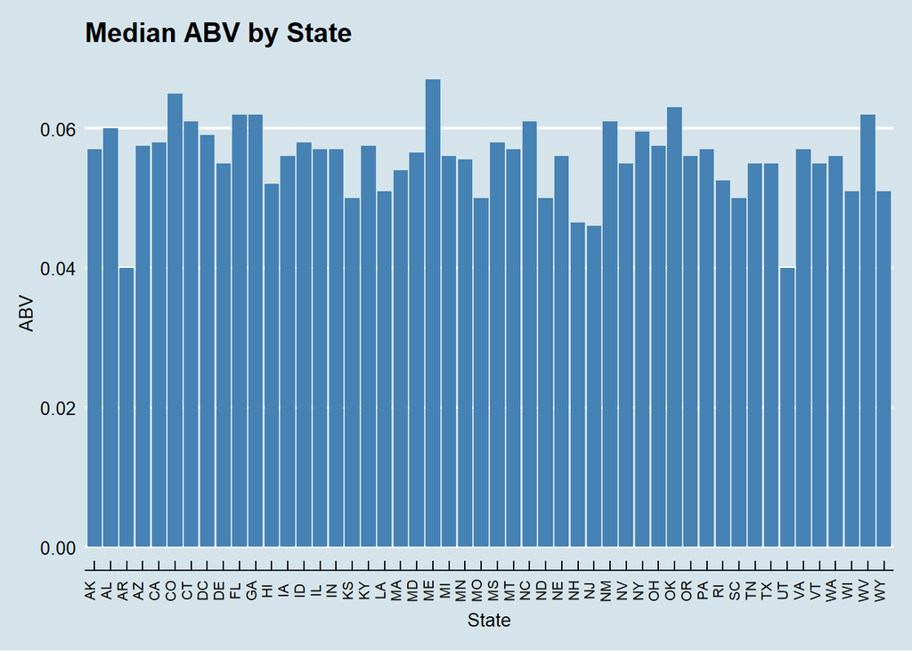

```r
# Compute the median alcohol content unit for each state.
Firewater <- BrewPub %>% na.omit() %>% group_by(State) %>% summarize(Median = median(ABV)) %>% arrange(Median)

# Compute the median international bitterness unit for each state.
Bitter <- BrewPub %>% na.omit() %>% group_by(State) %>% summarize(Median = median(IBU)) %>% arrange(Median)

# Plot a bar chart to compare ABV by state
ggplot(data=Firewater, aes(x=State, y=Median)) +
  geom_bar(stat="identity", fill="steelblue")+
  theme_economist() +
  scale_color_economist()+
  theme(axis.text.x=element_text(size=rel(0.8), angle=90)) +
  ggtitle("Median ABV by State") +
  labs(x="State",y="ABV")
```

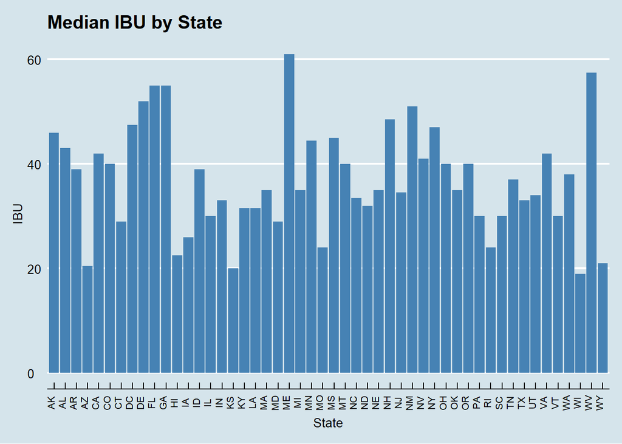

```r
# Plot a bar chart to compare IBU by state
ggplot(data=Bitter, aes(x=State, y=Median)) +
  geom_bar(stat="identity", fill="steelblue")+
  theme_economist() +
  scale_color_economist()+
  theme(axis.text.x=element_text(size=rel(0.8), angle=90))+
  ggtitle("Median IBU by State") +
  labs(x="State",y="IBU")
```

# 5. Which state has the maximum alcoholic (ABV) beer? Which state has the most bitter (IBU) beer?

```r
kable(BrewPub[which.max(BrewPub$ABV),])
```

|  | Name.x | Beer_ID | ABV | IBU | Brew_ID | Style | Ounces | Name.y | City | State |
| --- | --- | --- | --- | --- | --- | --- | --- | --- | --- | --- |
| 71 | London Balling | 2685 | 0.125 | 80 | 2 | English Barleywine | 16 | Against the Grain Brewery | Louisville | KY |

```r
kable(BrewPub[which.max(BrewPub$IBU),])
```

|  | Name.x | Beer_ID | ABV | IBU | Brew_ID | Style | Ounces | Name.y | City | State |
| --- | --- | --- | --- | --- | --- | --- | --- | --- | --- | --- |
| 148 | Bitter Bitch Imperial IPA | 980 | 0.082 | 138 | 375 | American Double / Imperial IPA | 12 | Astoria Brewing Company | Astoria | OR |

# 6. Comment on the summary statistics and distribution of the ABV variable.

```r
BeerSummary <- (summary(BrewPub$ABV))
print(BeerSummary)
```

```
##    Min. 1st Qu.  Median    Mean 3rd Qu.    Max.
## 0.02700 0.05000 0.05700 0.05991 0.06800 0.12500
```

# 7. Is there an apparent relationship between the bitterness of the beer and its alcoholic content? Draw a scatter plot. Make your best judgment of a relationship and EXPLAIN your answer.

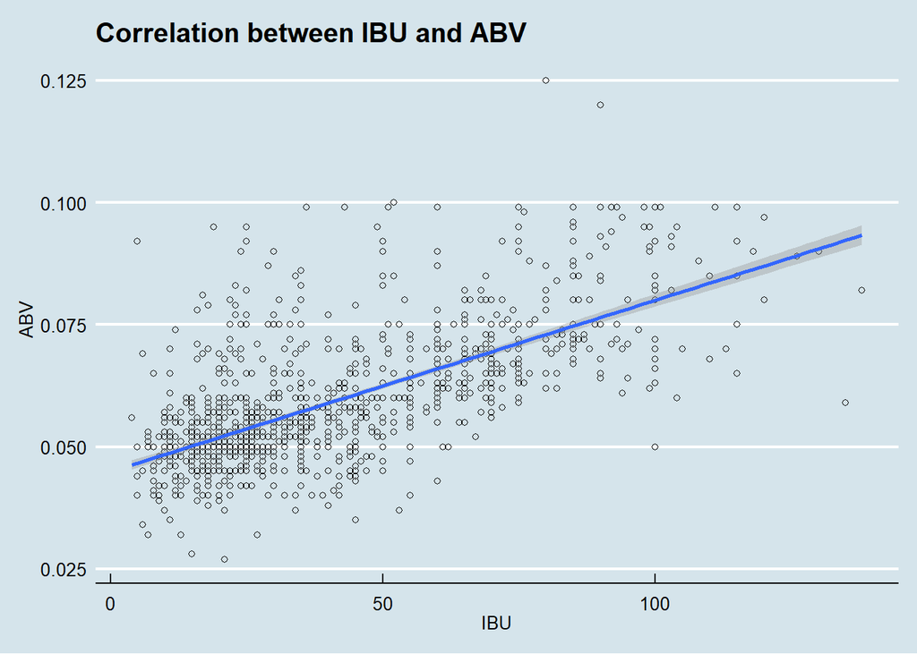

```r
# Draw a scatter plot to compare relationship between beer
# bitterness and alcohol content
ggplot(BrewPub, aes(x=IBU, y= ABV)) +
  geom_point(shape=1) +
   geom_smooth(method=lm) + # add linear regression line
  theme_economist() +
  scale_color_economist()+
  theme(axis.text.x=element_text(size=rel(1.0)))+
ggtitle("Correlation between IBU and ABV ") +
  labs(x="IBU",y="ABV")
```

```r
# Pearson's product-moment correlation
cor.test(BrewPub$ABV,BrewPub$IBU)
```

```
##
##  Pearson's product-moment correlation
##
## data:  BrewPub$ABV and BrewPub$IBU
## t = 33.863, df = 1403, p-value < 2.2e-16
## alternative hypothesis: true correlation is not equal to 0
## 95 percent confidence interval:
##  0.6407982 0.6984238
## sample estimates:
##       cor
## 0.6706215
```

# In this analysis, we examined data from two datasets regarding beers and breweries throughout the US. We examined the structure of this data, cleaned them, and combined them. We then performed various analyses, such as calculating median values for IBU and ABV by state, and determining which states had the beers with the highest ABV and IBU values. We finished by looking for a potential relationship between IBU and ABV, and found that there is evidence to suggest that a positive correlation exists between the two.

## Budweiser would also like to investigate the difference with respect to IBU and ABV between IPAs (India Pale Ales) and other types of Ale (any beer with “Ale” in its name other than IPA).

```r
BrewPub$BeerType <- ifelse(grepl("Ale$", BrewPub$Style, ignore.case = T), "Other Type Ale",
ifelse(grepl("IPA$", BrewPub$Style, ignore.case = T ), "India Pale Ale", "Other Type"))

BrewPub$BeerType = as.factor(BrewPub$BeerType)

# Inida Pale Ale v. Other Type Ale
set.seed(6)
splitPerc = .75
BrewPubIPAOther = BrewPub %>% filter(BeerType == "India Pale Ale" | BeerType == "Other Type Ale")
summary(BrewPubIPAOther)
```

```
##                  Name.x       Beer_ID            ABV
##  Nonstop Hef Hop    : 12   Min.   :   4.0   Min.   :0.0350
##  Dagger Falls IPA   :  3   1st Qu.: 792.5   1st Qu.:0.0520
##  312 Urban Wheat Ale:  2   Median :1487.0   Median :0.0620
##  Blacktop Blonde    :  2   Mean   :1427.0   Mean   :0.0629
##  BLAKKR             :  2   3rd Qu.:2071.5   3rd Qu.:0.0700
##  Bombshell Blonde   :  2   Max.   :2692.0   Max.   :0.0990
##  (Other)            :748
##       IBU            Brew_ID                                 Style
##  Min.   :  4.00   Min.   :  1.0   American IPA                  :301
##  1st Qu.: 24.00   1st Qu.: 94.0   American Amber / Red Ale      : 77
##  Median : 50.00   Median :204.0   American Double / Imperial IPA: 75
##  Mean   : 51.34   Mean   :223.5   American Blonde Ale           : 61
##  3rd Qu.: 70.50   3rd Qu.:337.5   American Pale Wheat Ale       : 61
##  Max.   :138.00   Max.   :547.0   American Brown Ale            : 38
##                                   (Other)                       :158
##      Ounces                             Name.y           City
##  Min.   :12.00   Hopworks Urban Brewery    : 19   Portland : 28
##  1st Qu.:12.00   Oskar Blues Brewery       : 14   San Diego: 24
##  Median :12.00   Cigar City Brewing Company: 13   Tampa    : 17
##  Mean   :13.59   Sixpoint Craft Ales       : 13   Seattle  : 15
##  3rd Qu.:16.00   Sun King Brewing Company  : 12   Boulder  : 14
##  Max.   :32.00   Big Sky Brewing Company   : 11   Brooklyn : 14
##                  (Other)                   :689   (Other)  :659
##      State               BeerType
##   CA    : 84   India Pale Ale:385
##   CO    : 71   Other Type    :  0
##   OR    : 56   Other Type Ale:386
##   TX    : 44
##   IN    : 40
##   FL    : 28
##  (Other):448
```

```r
BrewPubIPAOther = droplevels(BrewPubIPAOther, exclude = "Other Type")
summary(BrewPubIPAOther)
```

```
##                  Name.x       Beer_ID            ABV
##  Nonstop Hef Hop    : 12   Min.   :   4.0   Min.   :0.0350
##  Dagger Falls IPA   :  3   1st Qu.: 792.5   1st Qu.:0.0520
##  312 Urban Wheat Ale:  2   Median :1487.0   Median :0.0620
##  Blacktop Blonde    :  2   Mean   :1427.0   Mean   :0.0629
##  BLAKKR             :  2   3rd Qu.:2071.5   3rd Qu.:0.0700
##  Bombshell Blonde   :  2   Max.   :2692.0   Max.   :0.0990
##  (Other)            :748
##       IBU            Brew_ID                                 Style
##  Min.   :  4.00   Min.   :  1.0   American IPA                  :301
##  1st Qu.: 24.00   1st Qu.: 94.0   American Amber / Red Ale      : 77
##  Median : 50.00   Median :204.0   American Double / Imperial IPA: 75
##  Mean   : 51.34   Mean   :223.5   American Blonde Ale           : 61
##  3rd Qu.: 70.50   3rd Qu.:337.5   American Pale Wheat Ale       : 61
##  Max.   :138.00   Max.   :547.0   American Brown Ale            : 38
##                                   (Other)                       :158
##      Ounces                             Name.y           City
##  Min.   :12.00   Hopworks Urban Brewery    : 19   Portland : 28
##  1st Qu.:12.00   Oskar Blues Brewery       : 14   San Diego: 24
##  Median :12.00   Cigar City Brewing Company: 13   Tampa    : 17
##  Mean   :13.59   Sixpoint Craft Ales       : 13   Seattle  : 15
##  3rd Qu.:16.00   Sun King Brewing Company  : 12   Boulder  : 14
##  Max.   :32.00   Big Sky Brewing Company   : 11   Brooklyn : 14
##                  (Other)                   :689   (Other)  :659
##      State               BeerType
##   CA    : 84   India Pale Ale:385
##   CO    : 71   Other Type Ale:386
##   OR    : 56
##   TX    : 44
##   IN    : 40
##   FL    : 28
##  (Other):448
```

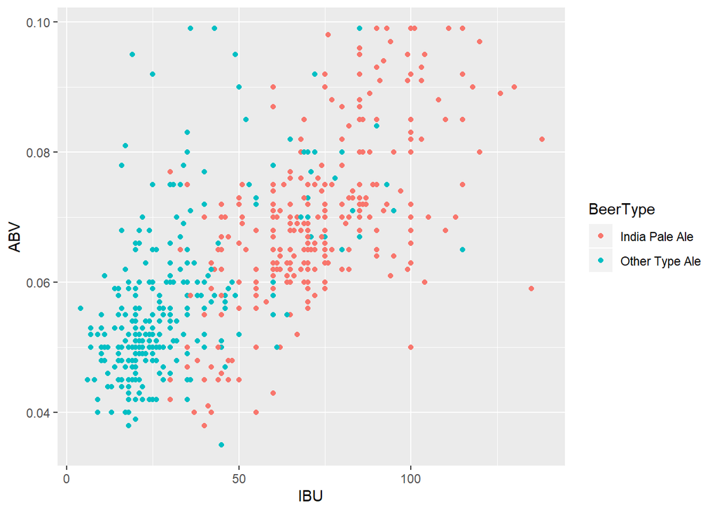

```r
BrewPubIPAOther <- BrewPubIPAOther %>% na.omit()

trainIndices = sample(1:dim(BrewPubIPAOther)[1],round(splitPerc * dim(BrewPubIPAOther)[1]))
train = BrewPubIPAOther[trainIndices,]
test = BrewPubIPAOther[-trainIndices,]

BrewPubIPAOther %>% ggplot(aes(x = IBU, ABV, color = BeerType)) + geom_point()
```

# Knn method to investigate the difference with respect to IBU and ABV between IPAs and Other Type of Ale

```r
# k = 3
classifications = knn(train[,c(3,4)],test[,c(3,4)],train$BeerType, prob = TRUE, k = 3)
table(classifications,test$BeerType)
```

```
##
## classifications  India Pale Ale Other Type Ale
##   India Pale Ale             79             16
##   Other Type Ale             10             88
```

```r
confusionMatrix(table(classifications,test$BeerType))
```

```
## Confusion Matrix and Statistics
##
##
## classifications  India Pale Ale Other Type Ale
##   India Pale Ale             79             16
##   Other Type Ale             10             88
##
##                Accuracy : 0.8653
##                  95% CI : (0.8089, 0.9101)
##     No Information Rate : 0.5389
##     P-Value [Acc > NIR] : <2e-16
##
##                   Kappa : 0.7302
##
##  Mcnemar's Test P-Value : 0.3268
##
##             Sensitivity : 0.8876
##             Specificity : 0.8462
##          Pos Pred Value : 0.8316
##          Neg Pred Value : 0.8980
##              Prevalence : 0.4611
##          Detection Rate : 0.4093
##    Detection Prevalence : 0.4922
##       Balanced Accuracy : 0.8669
##
##        'Positive' Class : India Pale Ale
##
```

```r
# k = 5
classifications = knn(train[,c(3,4)],test[,c(3,4)],train$BeerType, prob = TRUE, k = 5)
table(test$BeerType,classifications)
```

```
##                 classifications
##                  India Pale Ale Other Type Ale
##   India Pale Ale             81              8
##   Other Type Ale             16             88
```

```r
confusionMatrix(table(test$BeerType,classifications))
```

```
## Confusion Matrix and Statistics
##
##                 classifications
##                  India Pale Ale Other Type Ale
##   India Pale Ale             81              8
##   Other Type Ale             16             88
##
##                Accuracy : 0.8756
##                  95% CI : (0.8206, 0.9187)
##     No Information Rate : 0.5026
##     P-Value [Acc > NIR] : <2e-16
##
##                   Kappa : 0.7514
##
##  Mcnemar's Test P-Value : 0.153
##
##             Sensitivity : 0.8351
##             Specificity : 0.9167
##          Pos Pred Value : 0.9101
##          Neg Pred Value : 0.8462
##              Prevalence : 0.5026
##          Detection Rate : 0.4197
##    Detection Prevalence : 0.4611
##       Balanced Accuracy : 0.8759
##
##        'Positive' Class : India Pale Ale
##
```

```r
# k = 10
classifications = knn(train[,c(3,4)],test[,c(3,4)],train$BeerType, prob = TRUE, k = 10)
table(test$BeerType,classifications)
```

```
##                 classifications
##                  India Pale Ale Other Type Ale
##   India Pale Ale             83              6
##   Other Type Ale             17             87
```

```r
confusionMatrix(table(test$BeerType,classifications))
```

```
## Confusion Matrix and Statistics
##
##                 classifications
##                  India Pale Ale Other Type Ale
##   India Pale Ale             83              6
##   Other Type Ale             17             87
##
##                Accuracy : 0.8808
##                  95% CI : (0.8266, 0.9229)
##     No Information Rate : 0.5181
##     P-Value [Acc > NIR] : < 2e-16
##
##                   Kappa : 0.7623
##
##  Mcnemar's Test P-Value : 0.03706
##
##             Sensitivity : 0.8300
##             Specificity : 0.9355
##          Pos Pred Value : 0.9326
##          Neg Pred Value : 0.8365
##              Prevalence : 0.5181
##          Detection Rate : 0.4301
##    Detection Prevalence : 0.4611
##       Balanced Accuracy : 0.8827
##
##        'Positive' Class : India Pale Ale
##
```

```r
# k = 20
classifications = knn(train[,c(3,4)],test[,c(3,4)],train$BeerType, prob = TRUE, k = 20)
table(test$BeerType,classifications)
```

```
##                 classifications
##                  India Pale Ale Other Type Ale
##   India Pale Ale             83              6
##   Other Type Ale             18             86
```

```r
CM = confusionMatrix(table(test$BeerType,classifications))
CM$overall[1]
```

```
##  Accuracy
## 0.8756477
```

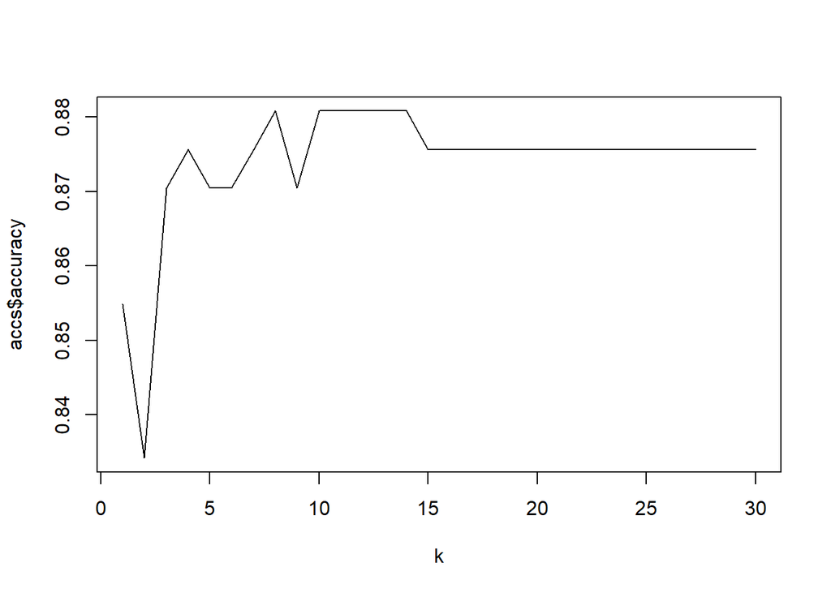

```r
## Loop for many k and one training / test partition
accs = data.frame(accuracy = numeric(30), k = numeric(30))

for(i in 1:30)
{
  classifications = knn(train[,c(3,4)],test[,c(3,4)],train$BeerType, prob = TRUE, k = i)
  table(test$BeerType,classifications)
  CM = confusionMatrix(table(test$BeerType,classifications))
  accs$accuracy[i] = CM$overall[1]
  accs$k[i] = i
}

plot(accs$k,accs$accuracy, type = "l", xlab = "k")
```

# Naive Bayes method to investigate the difference with respect to IBU and ABV between IPAs and Other Type of Ale

```r
model = naiveBayes(BrewPubIPAOther[,c(3,4)],BrewPubIPAOther$BeerType)
table(predict(model,BrewPubIPAOther[,c(3,4)]),BrewPubIPAOther$BeerType)
```

```
##
##                  India Pale Ale Other Type Ale
##   India Pale Ale            331             52
##   Other Type Ale             54            334
```

```r
CM = confusionMatrix(table(predict(model,BrewPubIPAOther[,c(3,4)]),BrewPubIPAOther$BeerType))
CM
```

```
## Confusion Matrix and Statistics
##
##
##                  India Pale Ale Other Type Ale
##   India Pale Ale            331             52
##   Other Type Ale             54            334
##
##                Accuracy : 0.8625
##                  95% CI : (0.8362, 0.886)
##     No Information Rate : 0.5006
##     P-Value [Acc > NIR] : <2e-16
##
##                   Kappa : 0.725
##
##  Mcnemar's Test P-Value : 0.9226
##
##             Sensitivity : 0.8597
##             Specificity : 0.8653
##          Pos Pred Value : 0.8642
##          Neg Pred Value : 0.8608
##              Prevalence : 0.4994
##          Detection Rate : 0.4293
##    Detection Prevalence : 0.4968
##       Balanced Accuracy : 0.8625
##
##        'Positive' Class : India Pale Ale
##
```

```r
iterations = 100
masterAcc = matrix(nrow = iterations)
splitPerc = .7 #Training / Test split Percentage
for(j in 1:iterations)
{
  trainIndices = sample(1:dim(BrewPubIPAOther)[1],round(splitPerc * dim(BrewPubIPAOther)[1]))
  train = BrewPubIPAOther[trainIndices,]
  test = BrewPubIPAOther[-trainIndices,]

  model = naiveBayes(train[,c(3,4)],as.factor(train$BeerType))
  table(predict(model,test[,c(3,4)]),as.factor(test$BeerType))
  CM = confusionMatrix(table(predict(model,test[,c(3,4)]),as.factor(test$BeerType)))
  masterAcc[j] = CM$overall[1]
}
MeanAcc = colMeans(masterAcc)
MeanAcc
```

```
## [1] 0.8624675
```